# 4. Simple Linear Regression III

MATH 261A: Regression Theory and Methods

Peter A. Gao

## Coding exercises

Use simulation to demonstrate that for the simple linear regression model, even if the errors have unequal variances, as long as they have mean zero, the least squares estimators are unbiased.

## Class outline

- Understand simple linear regression from the analysis of variance point of view
- Discuss F tests
- Coefficient of determination ($r$-squared) and correlation ($r$)

## Warm-up: Scatterplot charades

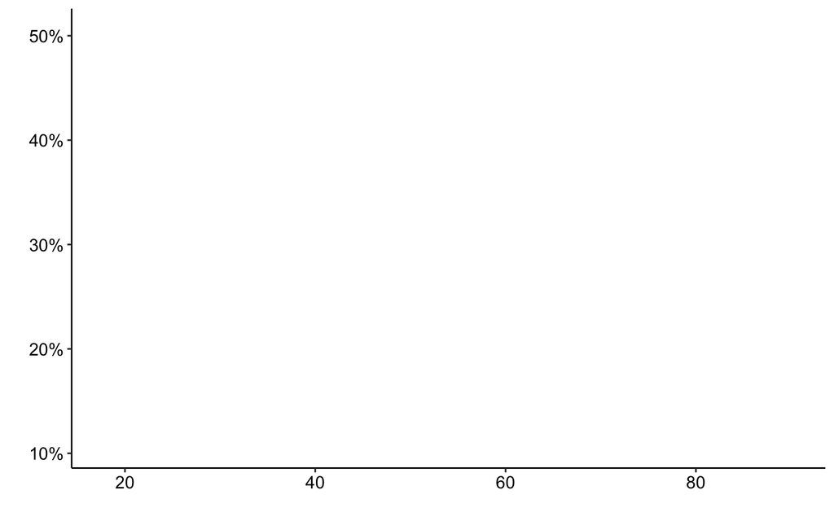

## Warm-up: Scatterplot charades

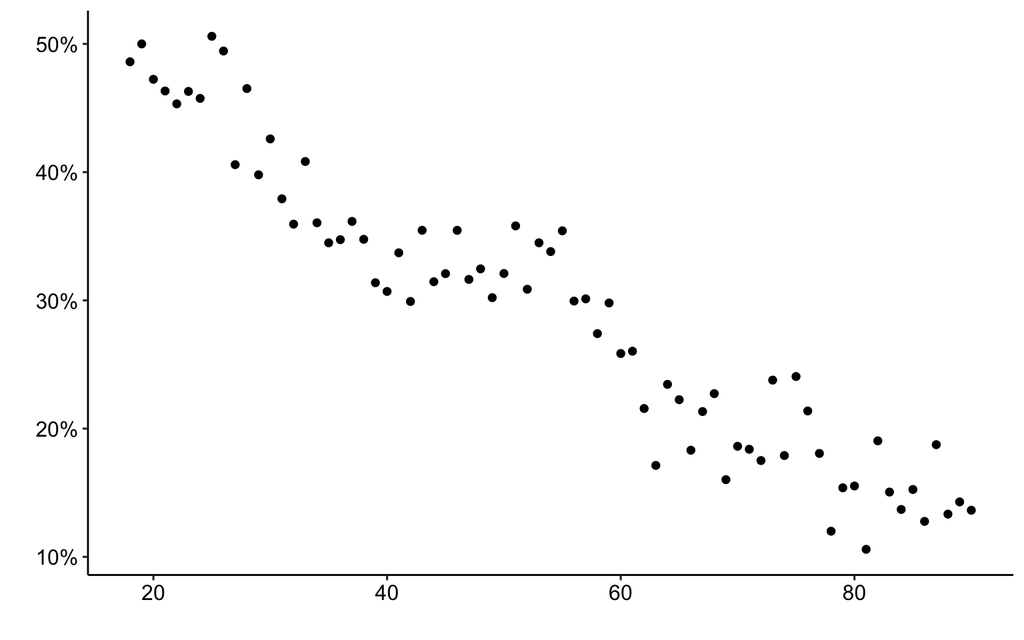

## Warm-up: Scatterplot charades

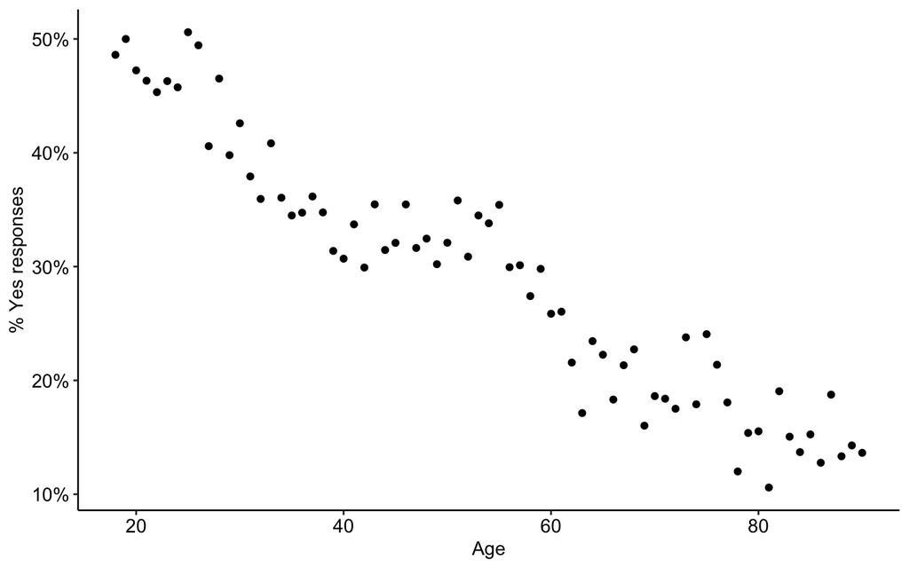

## Warm-up: Scatterplot charades

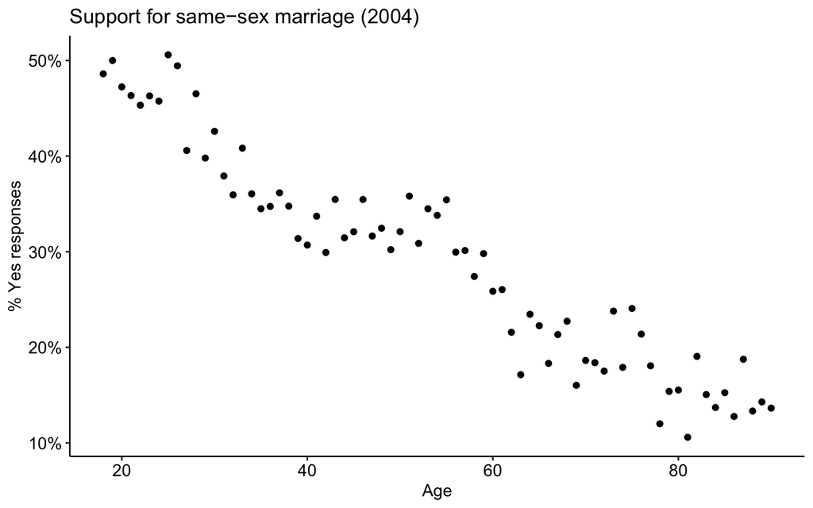

## History of ANOVA

Broadly speaking, analysis of variance (ANOVA) assesses differences between group means by comparing the variation between group means with the variation within each group.

In his book **Statistical Methods for Research Workers** (1925), R.A. Fisher developed ANOVA methods for assessing whether differences in wheat crop yields between groups receiving different fertilizers were statistically significant.

## Analysis of variance: intuition

ANOVA has historically been presented as a method for assessing the effect of a **categorical** predictor, but understanding its application to **continuous** predictors will help us develop a general framework for assessing the fit of linear models.

**Intuition.** The goal is to quantify and decompose the total variation in some outcome variable $Y$ (ex. final exam score):

$$\begin{align*}\textrm{total variation in Y}&=\text{variation explained by model}\\ &\;\;\;\;+\;\; \text{residual variation}
\end{align*}$$

If the variation explained by the model is a substantial portion of the total variation, then perhaps the model is a good fit to the data.

## Does this look like a good fit?

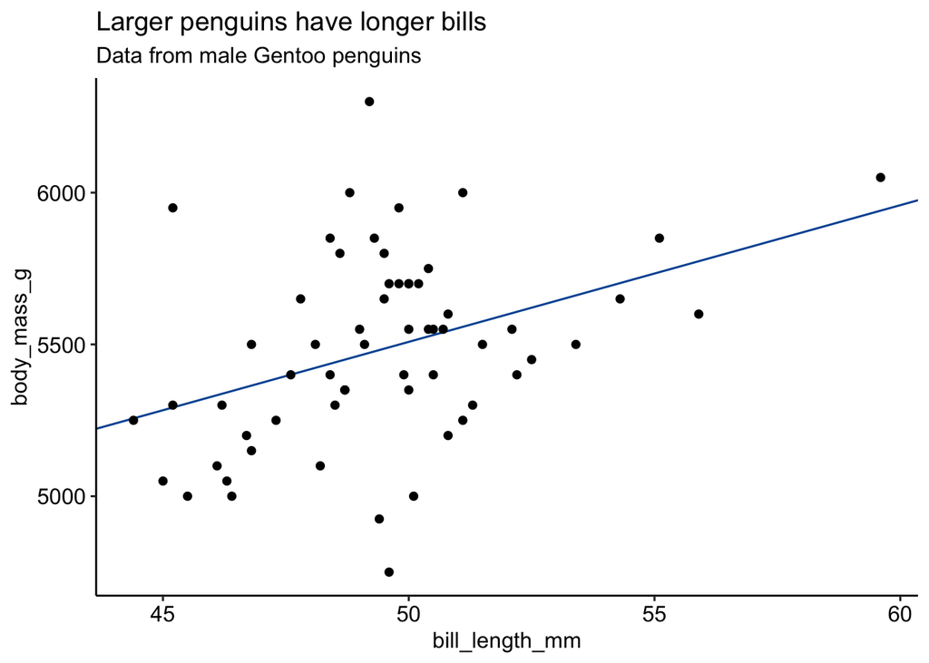

```r
library(palmerpenguins)
data(penguins)
gentoo <- penguins |>
  filter(species == "Gentoo", sex == "male")
lm_fit <- lm(body_mass_g ~ bill_length_mm, data = gentoo)
ggplot(gentoo, aes(x = bill_length_mm, y = body_mass_g)) +
  geom_abline(slope = lm_fit$coefficients[2],
              intercept = lm_fit$coefficients[1], color = "#0055A2") +
  geom_point() +
  ggtitle("Larger penguins have longer bills",
          subtitle = "Data from male Gentoo penguins") +
  theme_pubr()
```

## Decomposition of total variation in $Y$

Consider the deviations from the mean, which represent the **total variation** in $Y$:

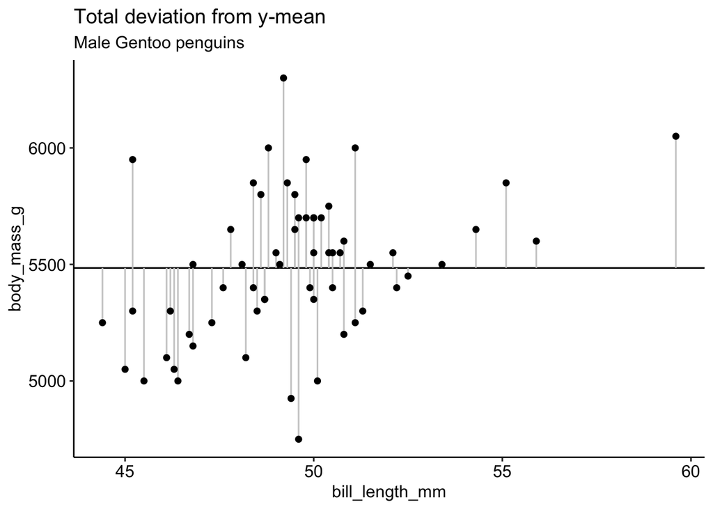

```r
ybar <- mean(gentoo$body_mass_g, na.rm = T)
p1 <- ggplot(gentoo, aes(x = bill_length_mm, y = body_mass_g)) +
  geom_hline(yintercept = ybar) +
  geom_segment(aes(xend = bill_length_mm, yend = ybar), color = "gray80") +
  geom_point() +
  ggtitle("Total deviation from y-mean",
          subtitle = "Male Gentoo penguins") +
  theme_pubr()
print(p1)
```

## Decomposition of total variation in $Y$

We can decompose these deviations into the **deviation around the regression line**:

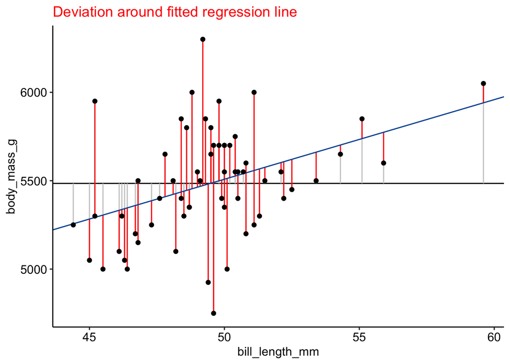

```r
p2 <- ggplot(gentoo, aes(x = bill_length_mm, y = body_mass_g)) +
  geom_hline(yintercept = ybar) +
  geom_segment(aes(xend = bill_length_mm, yend = ybar), color = "gray80") +
  geom_segment(aes(xend = bill_length_mm, yend = lm_fit$fitted.values),
               color = "red") +
  geom_abline(slope = lm_fit$coefficients[2],
              intercept = lm_fit$coefficients[1], color = "#0055A2") +
  geom_point() +
  theme_pubr() +
  ggtitle("Deviation around fitted regression line") +
  theme(plot.title = element_text(color = "red"))
print(p2)
```

## Decomposition of total variation in $Y$

And the **deviations from the mean line to the regression line*:

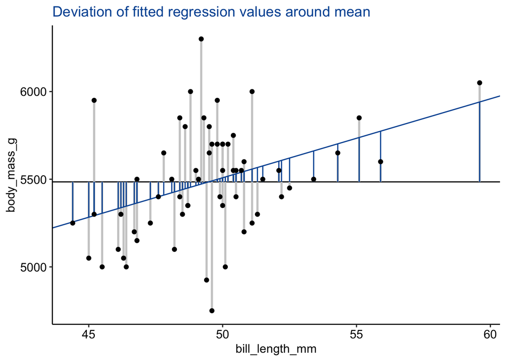

```r
p3 <- ggplot(gentoo, aes(x = bill_length_mm, y = body_mass_g)) +
  geom_hline(yintercept = ybar) +
  geom_segment(aes(xend = bill_length_mm, yend = ybar),
               color = "gray80", linewidth = 1) +
  geom_segment(aes(xend = bill_length_mm,
                   y = lm_fit$fitted.values,
                   yend = ybar),
               color = "#0055A2") +
  geom_abline(slope = lm_fit$coefficients[2],
              intercept = lm_fit$coefficients[1], color = "#0055A2") +
  geom_point() +
  theme_pubr() +
  ggtitle("Deviation of fitted regression values around mean") +
  theme(plot.title = element_text(color = "#0055A2"))
print(p3)
```

## Decomposition of total variation in $Y$

```r
library(patchwork)
p1 + p3 + p2
```

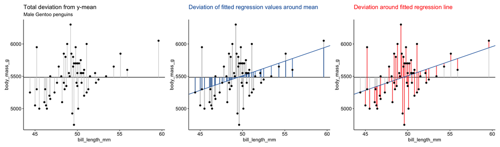

## Formal decomposition of total variation in $Y$

Let $Y_i$ denote the $i$th response, and $\overline{Y}$ the sample mean of $Y_1,\ldots, Y_n$. Let $\widehat{Y}_i$ denote the fitted value for the $i$th unit based on the fitted regression line.

$$\begin{align*}
\underbrace{Y_i-\overline{Y}}_{\textrm{Total deviation}} = \color{MidnightBlue}{\underbrace{\widehat{Y}_i-\overline{Y}}_{\substack{\text{deviation of fitted} \\ \text{values around mean}}}} + \color{red}{\underbrace{Y_i-\widehat{Y}_i}_{\substack{\text{deviation around} \\ \text{regression line}}}}
\end{align*}$$

Remarkably, the same decomposition is true for the sums of the squared deviations (see KNNL p. 65 for proof).

$$\sum_{i=1}^n (Y_i-\overline{Y})^2 = \color{MidnightBlue}{\sum_{i=1}^n (\widehat{Y}_i-\overline{Y})^2} + \color{red}{\sum_{i=1}^n (Y_i-\widehat{Y}_i)^2}$$

## Decomposition of sums of squares

$$\sum_{i=1}^n (Y_i-\overline{Y})^2 = \color{MidnightBlue}{\sum_{i=1}^n (\widehat{Y}_i-\overline{Y})^2} + \color{red}{\sum_{i=1}^n (Y_i-\widehat{Y}_i)^2}$$

Using the notation from KNNL Equation (2.50)

$$SSTO = \color{MidnightBlue}{SSR} + \color{Red}{SSE}$$
where

- $SSTO$ is called the total sum of squares
- $SSR$ is called the regression sum of squares
- $SSE$ is called the error sum of squares

The larger $SSR$ is in relation to $SSTO$, the larger is the explanatory power of the regression function.

## Penguins revisited

```r
y <- gentoo$body_mass_g
ybar <- mean(gentoo$body_mass_g, na.rm = T)
lm_fit <- lm(body_mass_g ~ bill_length_mm, data = gentoo)
yhat <- lm_fit$fitted.values
SSTO <- sum((y - ybar) ^ 2)
SSR <- sum((yhat - ybar) ^ 2)
SSE <- sum((y - yhat) ^ 2)
print(paste0("SSTO: ", SSTO, ", SSR: ", SSR, ", SSE: ", SSE))
```

```
[1] "SSTO: 5884098.36065574, SSR: 900993.675131792, SSE: 4983104.68552394"
```

```r
print(SSE + SSR)
```

```
[1] 5884098
```

How do we decide if $SSR$ is *large* with respect to $SSTO$, indicating that the regression model explains a large proportion of the total variation?

## Degrees of Freedom

Each sum of squares is associated with a number of degrees of freedom.

- $SSTO$ has $n-1$ degrees of freedom (since we estimate the population mean via the sample mean)
- $SSE$ has $n-2$ degrees of freedom (since we estimate $\beta_0$ and $\beta_1$)
- $SSR$ has one degree of freedom. (all $\overline{Y}_i$ are calculated based on one line which has two parameters with one constraint, which is that the deviations sum to zero).

The degrees of freedom are additive:
$$n-1=1 + (n-2)$$

## Mean square terms

Dividing a sum of squares by its degrees of freedom allows us to calculate a mean square term:

The mean square due to regression is:

$$MSR = \frac{SSR}{1}=SSR$$

The mean square due to errors is:

$$MSE=\frac{SSE}{n-2}$$

Later, we will see how we can use a statistical test to compare $MSR$ and $MSE$.

## Analysis of variance table

After fitting a simple linear regression, we can summarize this decomposition using an **analysis of variance** table, which will typically look something like this:

| Source | Df | Sum Sq | Mean Sq | F value | Pr($>$F) |
| --- | --- | --- | --- | --- | --- |
| Regression | $1$ | $SSR$ | $MSR$ | $F = \dfrac{MSR}{MSE}$ | $p$-value |
| Residual | $n-2$ | $SSE$ | $MSE$ |  |  |
| Total | $n-1$ | $SSTO$ |  |  |  |

If we wish to assess the fit of the model, we can perform a hypothesis test using the $F$-value $F = \dfrac{MSR}{MSE}$ as a test statistic.

## Analysis of variance table: penguins

```r
lm_fit <- lm(body_mass_g ~ bill_length_mm, data = gentoo)
anova(lm_fit)
```

```
Analysis of Variance Table

Response: body_mass_g
               Df  Sum Sq Mean Sq F value   Pr(>F)
bill_length_mm  1  900994  900994  10.668 0.001819 **
Residuals      59 4983105   84459
---
Signif. codes:  0 '***' 0.001 '**' 0.01 '*' 0.05 '.' 0.1 ' ' 1
```

## Expected mean squares

If $MSR$ is large compared with $MSE$, then we can say the regression line explains part of the variation in $Y$. But what counts as *large*?

We have already seen that
$$E(MSE) =\sigma^2$$
In addition (see KNNL p. 69):
$$E(MSR)=\sigma^2 +\beta_1^2\sum_i(X_i-\overline{X})^2$$

Observe that when $\beta_1=0$, $E(MSR)=\sigma^2=E(MSE)$.

Therefore, if $MSR$ is substantially greater than $MSE$, this would suggest that $\beta_1\not=0$.

## $F$ test of $H_0:\beta_1=0$ versus $H_a: \beta_1\not=0$

**Test statistic.** Consider the following test statistic:

$$F^*=\frac{MSR}{MSE}$$

Intuitively, large values of $F^*$ provide support for $H_a$, while values of $F^*$ near 1 support $H_0$.

**Sampling distribution of $F^*$ under $H_0$.** As with any hypothesis test, we compare the observed test statistic with its distribution under the null.

## Sampling distribution of $F^*$ under $H_0$

As a result of Cochran’s theorem (KNNL p. 70):

If $Y_1,\ldots Y_n$ are iid $N(\beta_0,\sigma^2)$, so $\beta_1=0$, then $SSR/\sigma^2$ is $\chi^2(1)$ and $SSE/\sigma^2$ is $\chi^2(n-2)$ and the two are independent.

Then

$$F^*=MSR/MSE = \frac{\frac{SSR}{\sigma^2}}{1}\div\frac{\frac{SSE}{\sigma^2}}{n-2}$$
is a ratio of $\chi^2$ variables (each divided by its degrees of freedom).

## Sampling distribution of $F^*$ under $H_0$

In particular, for a simple linear regression model,

$$F^*=MSR/MSE \sim \frac{\chi^2(1)}{1}\div \frac{\chi^2(n-2)}{n-2}\textrm{ under }H_0$$

A random variable defined in this way follows Snedecor’s **F distribution** or the Fisher–Snedecor distribution.

The F-distribution with $\nu_1$ and $\nu_2$ degrees of freedom is the distribution of

$${\displaystyle F(\nu_1,\nu_2)={\frac {U_{1}/\nu_{1}}{U_{2}/\nu_{2}}}}$$

where $U_1$ and $U_2$ are independent $\chi^2$ variables with $\nu_1$ and $\nu_2$ degrees of freedom, respectively.

## $F$-distribution: Illustration

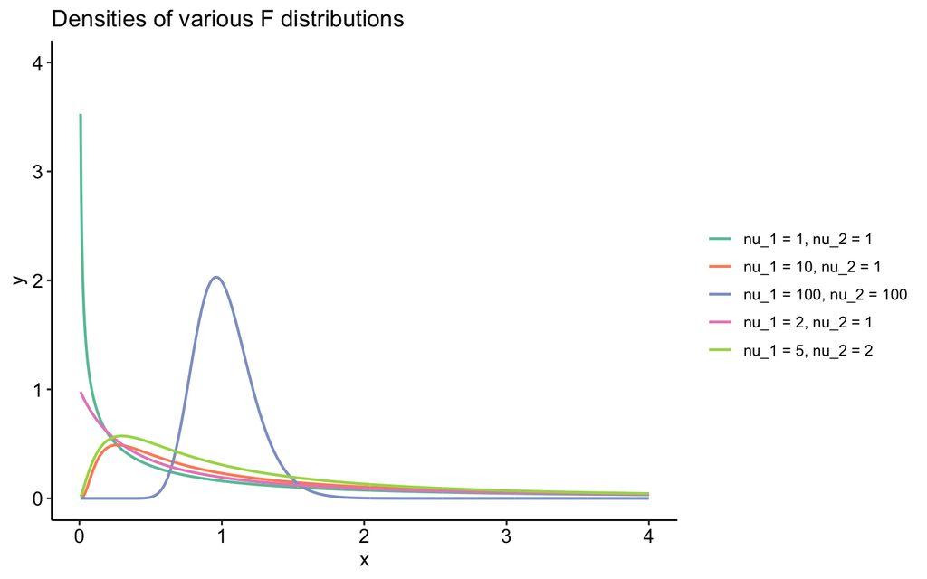

```r
library(RColorBrewer)
dat <- data.frame(nu1 = c(1, 2, 5, 10, 100),
                  nu2 = c(1, 1, 2, 1, 100)) |>
  mutate(id = paste0("nu_1 = ", nu1, ", nu_2 = ", nu2))
dat <- expand_grid(dat, x = seq(0, 4, length.out = 1000)) |>
  mutate(y = df(x, nu1, nu2))

ggplot(dat, aes(x = x, y = y, color = id)) +
  geom_line(linewidth = .8) +
  xlim(0.005, 4) +
  ylim(0, 4) +
  scale_color_brewer(palette = "Set2", name = "") +
  theme_pubr() +
  theme(legend.position = "right") +
  ggtitle("Densities of various F distributions")
```

## $F$-distribution

The $F$ distribution with $\nu_1$ and $\nu_2$ degrees of freedom has the probability density function

$$f(x) = {\displaystyle {\frac {\sqrt {\frac {(\nu_1x)^{\nu_1}\nu_2^{\nu_2}}{(\nu_1x+\nu_2)^{\nu_1+\nu_2}}}}{x\,\mathrm {B} \!\left({\frac {\nu_1}{2}},{\frac {\nu_2}{2}}\right)}}\!}$$

where $B$ denotes the beta function:

$${\displaystyle \mathrm {B} (z_{1},z_{2})=\int _{0}^{1}t^{z_{1}-1}(1-t)^{z_{2}-1}\,dt}$$

If $X\sim F(\nu_1,\nu_2)$, then

$$E(X)={\displaystyle {\frac {\nu_{2}}{\nu_{2}-2}}\!} \textrm{ when }\nu_2>2$$
$$\mathrm{Var}(X)={\displaystyle {\frac {2\,\nu_2^{2}\,(\nu_1+\nu_2-2)}{\nu_1(\nu_2-2)^{2}(\nu_2-4)}}\!} \textrm{ when }\nu_2>4$$

## Decision rule for $F$-test

We use an upper-tail test that compares $F^*$ with the null sampling distribution $F(1, n-2)$. Let $F_{1-\alpha;1, n-2}$ be the $(1-\alpha)100$% percentile of the $F(1, n-2)$ distribution.

Then, the decision rule is

$$\begin{align*}
\textrm{If } F^*&\leq F_{1-\alpha;1, n-2}\textrm{, fail to reject }H_0,\\
\textrm{If } F^*&> F_{1-\alpha;1, n-2}\textrm{, reject }H_0
\end{align*}$$

## Penguins example, illustrated

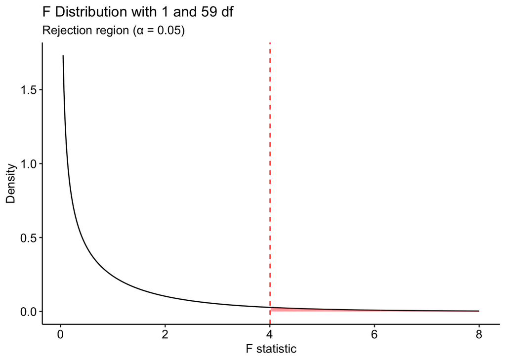

```r
# Parameters
df1 <- 1
df2 <- 59
alpha <- 0.05

# Critical value
f_crit <- qf(1 - alpha, df1, df2)

# Data for density curve
x <- seq(0.05, 8, length.out = 500)
y <- df(x, df1, df2)
df_data <- data.frame(x, y)

# Data for shaded rejection region
df_shade <- subset(df_data, x >= f_crit)

# Plot
ggplot(df_data, aes(x, y)) +
  geom_line(color = "black") +
  geom_area(data = df_shade, aes(x, y), fill = "red", alpha = 0.4) +
  geom_vline(xintercept = f_crit, linetype = "dashed", color = "red") +
  labs(
    title = paste0("F Distribution with ", df1, " and ", df2, " df"),
    subtitle = paste0("Rejection region (α = ", alpha, ")"),
    x = "F statistic",
    y = "Density"
  ) +
  theme_pubr()
```

## Penguins example, illustrated

```r
lm_fit <- lm(body_mass_g ~ bill_length_mm, data = gentoo)
anova(lm_fit)
```

```
Analysis of Variance Table

Response: body_mass_g
               Df  Sum Sq Mean Sq F value   Pr(>F)
bill_length_mm  1  900994  900994  10.668 0.001819 **
Residuals      59 4983105   84459
---
Signif. codes:  0 '***' 0.001 '**' 0.01 '*' 0.05 '.' 0.1 ' ' 1
```

## Penguins example, illustrated

Note that for simple linear regression, this is equivalent to the $t$-test for $\beta_1=0$ vs. $\beta_1\not=0$ we saw earlier (in fact, $F^*=(t^*)^2$):

```r
summary(lm_fit)
```

```
Call:
lm(formula = body_mass_g ~ bill_length_mm, data = gentoo)

Residuals:
   Min     1Q Median     3Q    Max
-740.5 -171.1   -6.3  182.4  827.5

Coefficients:
               Estimate Std. Error t value Pr(>|t|)
(Intercept)     3256.42     683.29   4.766 1.27e-05 ***
bill_length_mm    45.04      13.79   3.266  0.00182 **
---
Signif. codes:  0 '***' 0.001 '**' 0.01 '*' 0.05 '.' 0.1 ' ' 1

Residual standard error: 290.6 on 59 degrees of freedom
Multiple R-squared:  0.1531,    Adjusted R-squared:  0.1388
F-statistic: 10.67 on 1 and 59 DF,  p-value: 0.001819
```

## Coefficient of determination

There is, unfortunately, no single measure that describes whether a regression model is useful. Usefulness is always context dependent: ex. how accurate do your predictions need to be?

Nevertheless, you will often see the $R^2$ value reported as a measure of the model’s explanatory power.

$R^2$ is called the **coefficient of determination** and is defined as the proportion of variation explained by the regression model:

$$R^2=\frac{SSR}{SSTO}=1-\frac{SSE}{SSTO}$$

## Coefficient of determination: pitfalls

1. High $R^2$ does not necessarily mean we can make useful predictions.
2. High $R^2$ does not necessarily mean the estimated regression line is a good fit.
3. Low $R^2$ does not necessarily mean that $X$ and $Y$ are not related.

## Coefficient of determination: pitfalls

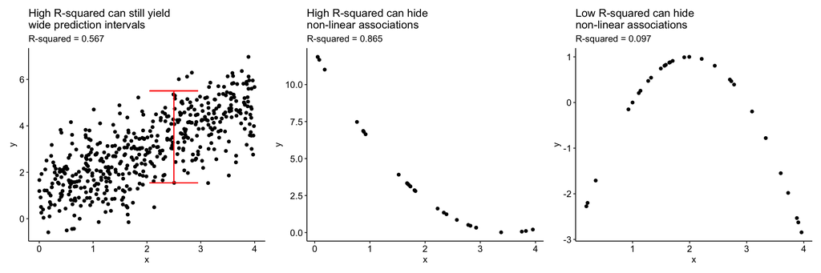

```r
library(patchwork)
set.seed(123)
n <- 500
x <- runif(n, 0, 4)
y <- x + rnorm(n, 1)
dat <- data.frame(x, y)
lm_fit <- lm(y ~ x)
pred_int <- predict(lm_fit, data.frame(x = 2.5), interval = "prediction")
p1 <- ggplot(dat, aes(x = x, y = y)) +
  geom_point() +
  geom_errorbar(color = "red", aes(x = 2.5, ymax = pred_int[3], ymin = pred_int[2])) +
  ggtitle("High R-squared can still yield \nwide prediction intervals",
          subtitle = paste0("R-squared = ", round(cor(x, y)^2, 3))) +
  theme_pubr()
n <- 30
x <- runif(n, 0, 4)
y <- (x - 3.5) ^ 2
dat <- data.frame(x, y)
p2 <- ggplot(dat, aes(x = x, y = y)) +
  geom_point() +
  ggtitle("High R-squared can hide \nnon-linear associations",
          subtitle = paste0("R-squared = ", round(cor(x, y)^2, 3))) +
  theme_pubr()
x <- runif(n, 0, 4)
y <- -1 * (x - 2) ^ 2 + 1
dat <- data.frame(x, y)
p3 <- ggplot(dat, aes(x = x, y = y)) +
  geom_point() +
  ggtitle("Low R-squared can hide \nnon-linear associations",
          subtitle = paste0("R-squared = ", round(cor(x, y)^2, 3))) +
  theme_pubr()
p1 + p2 + p3
```

## Coefficient of correlation

$R^2$ is of course related to the **correlation coefficient**, which quantifies the strength of the **linear** association between $X$ and $Y$:

$$r =\pm \sqrt{R^2}$$

where the sign depends on the direction of the association (negative sign for negative association, and vice versa).

## Class outline

- Assumptions, diagnostics, and model evaluation
- Discuss properties of residuals
- Possible remedial measure
- Coding exercises

## Review: simple linear regression model

Recall the **simple** linear regression with one outcome and one predictor. The model is typically written out:

$$Y_i=\beta_0+\beta_1 X_i +\varepsilon_i$$
where:

- $Y_i$ is the value of the $i$th outcome
- $\beta_0$ is the intercept parameter and $\beta_1$ is the slope parameter
- $X_i$ is a **known** constant representing the $i$th predictor
- $\varepsilon_i$ is a random error with mean zero and finite variance $\sigma^2$; all errors are independent, so if $i\not=j$, $\varepsilon_i$ and $\varepsilon_j$ are independent (in certain cases we may want to assume normality of $\varepsilon_i$)
- $i = 1,\ldots, n$

## Assumptions of simple linear regression

*In decreasing order of importance (ROS Ch. 11):*

1. **Validity.** The variables used should accurately reflect the quantities of interest, the model should include all relevant predictors, and the model should be applicable for the research question.

**Check:**

- *Is the data appropriate for the research question?* ex. If the goal is to study the effect of sleep on cognitive development, data on grades in school may not give the full picture.
- *Is regression necessary to answer your research question?* ex. If you wish to show that prices have increased over time, a plot of the Consumer Price Index over time may be sufficient.

## Assumptions of simple linear regression

2. **Representativeness.** The sample data is representative of the population of interest (after conditioning on the predictor variables).

**Check:**

- *Is the sample systematically different from the population, in a way that we can’t include in our model?* For example, if we wish to study the association between height and earnings, it may be okay to have an overrepresentation of taller people. However, if older people are overrepresented (and the relationship between $Y$ and $X$ varies across age), then our model may be unreasonable.
- *If we are making predictions, is the new case like the existing data?* If we wish to make predictions for a future event (like an election), our model will only be useful if the future case resembles the past cases.

## Assumptions of simple linear regression

3. **Additivity and linearity.** The mean function must be correct:

$$E(Y_i\mid X_i)=\beta_0+\beta_1 X_i$$

**Check:**

- *Does a linear model make sense for the mean relationship between $Y$ and $X$?* Would a nonlinear function make more sense? For example $E(Y_i\mid X_i)=\exp(\beta_1 X_i)$. In some cases, transformation can be used to create a linear relationship.

## Assumptions of simple linear regression

4. **Independence of errors.** The simple linear regression model assumes errors are independent, which may be violated when data are correlated in time or space, or when observations are clustered.
5. **Equal variance of errors.** Unequal error variance (heteroskedasticity) is a common issue that affects inference with the regression model.

These issues may not necessarily prevent us from unbiased estimation of the regression line, but if these assumptions are broken, OLS may be inefficient, meaning the parameter estimates are not optimal in terms of variance.

## Assumptions of simple linear regression

6. **Normality of errors.** Normality of errors enables inference with small samples, enabling us to conduct hypothesis tests even when the sample is small. However, for the purpose of estimating the regression line, normality is not critical. For this reason, we will not worry so much about the normality of errors.

## Simple linear regression, step by step

1. Starting with a research question, propose a regression analysis. Identify the dataset and the predictor/outcome variables. Identify the goal(s): Inference on $\beta_1$? Prediction of new cases? Identify the necessary assumptions and assess whether any issues are likely to arise.

ex. Propose a strategy for using regression to answer the question: *Are people with shorter work commutes happier?*

ex. Propose a strategy for using regression to answer the question: *Can we predict students’ college grades based on their SAT scores?*

## Simple linear regression, step by step

2. Clean the data and then summarize/visualize the predictor and outcome variables.
3. Fit the linear regression and assess the model fit.
4. If everything seems satisfactory, use the fitted model to answer your research question.
5. Present your analysis, describing all steps necessary to reproduce your results. Discuss any caveats or limitations of your analysis.

## Your friend, the scatter plot

What can we say about the fit of the following regression model?

```r
set.seed(123)

# Two groups with non-overlapping x ranges and the same negative slope,
# but different intercepts -> pooled trend flips positive.
n  <- 200
xA <- runif(n, 0, 40)
yA <- 50  - 0.6*xA + rnorm(n, 0, 3)
xB <- runif(n, 60, 100)
yB <- 130 - 0.6*xB + rnorm(n, 0, 3)

df <- rbind(
  data.frame(group = "A", x = xA, y = yA),
  data.frame(group = "B", x = xB, y = yB)
)
summary(lm(y ~ x, data = df))
```

```
Call:
lm(formula = y ~ x, data = df)

Residuals:
    Min      1Q  Median      3Q     Max
-29.237 -11.618  -0.533  11.013  33.169

Coefficients:
            Estimate Std. Error t value Pr(>|t|)
(Intercept) 31.28304    1.36194   22.97   <2e-16 ***
x            0.57551    0.02298   25.04   <2e-16 ***
---
Signif. codes:  0 '***' 0.001 '**' 0.01 '*' 0.05 '.' 0.1 ' ' 1

Residual standard error: 14.62 on 398 degrees of freedom
Multiple R-squared:  0.6118,    Adjusted R-squared:  0.6108
F-statistic: 627.1 on 1 and 398 DF,  p-value: < 2.2e-16
```

## Your friend, the scatter plot

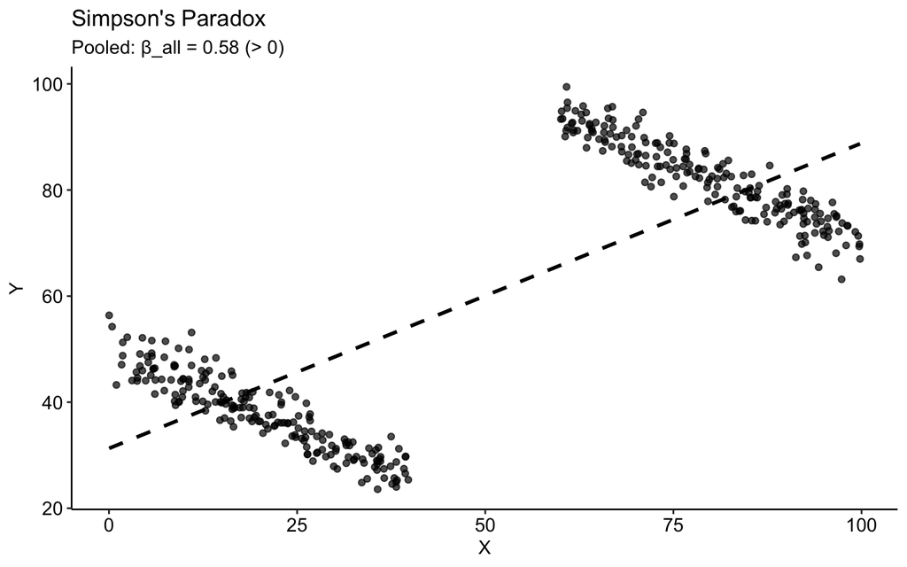

```r
# Fit slopes to show the paradox numerically
b_all <- coef(lm(y ~ x, data = df))[2]
b_A   <- coef(lm(y ~ x, data = df, subset = group == "A"))[2]
b_B   <- coef(lm(y ~ x, data = df, subset = group == "B"))[2]
ggplot(df, aes(x, y)) +
  geom_point(alpha = 0.7, size = 1.6) +
  # Pooled regression line (dashed, positive slope)
  geom_smooth(
    data = df,
    mapping = aes(x, y),
    method = "lm",
    se = FALSE,
    color = "black",
    linetype = "dashed",
    size = 1.1
  ) +
  labs(
    title = "Simpson's Paradox",
    subtitle = paste0(
      "Pooled: β_all = ", sprintf("%.2f", b_all), " (> 0)"
    ),
    x = "X",
    y = "Y"
  ) +
  theme_pubr()
```

## Your friend, the scatter plot

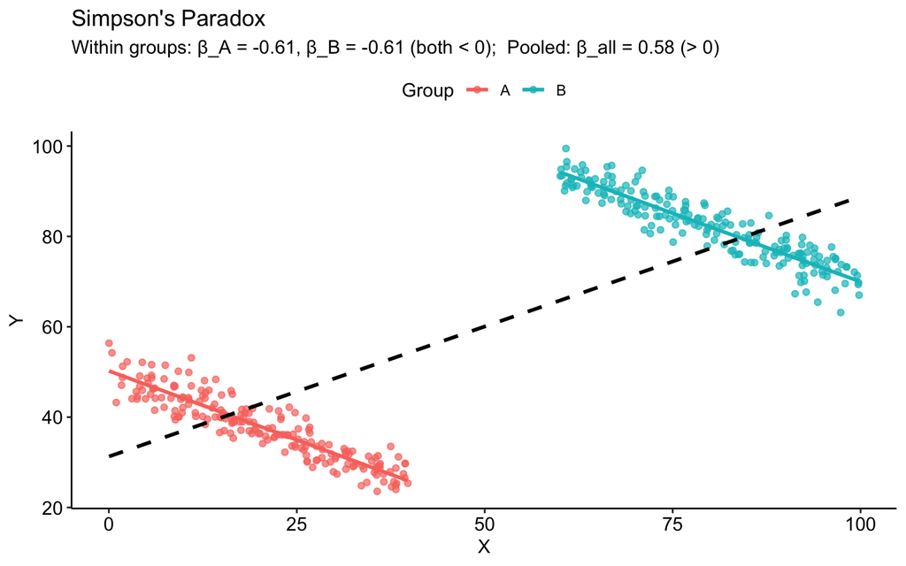

```r
# Fit slopes to show the paradox numerically
b_all <- coef(lm(y ~ x, data = df))[2]
b_A   <- coef(lm(y ~ x, data = df, subset = group == "A"))[2]
b_B   <- coef(lm(y ~ x, data = df, subset = group == "B"))[2]
ggplot(df, aes(x, y, color = group)) +
  geom_point(alpha = 0.7, size = 1.6) +
  # Within-group regression lines (both negative)
  geom_smooth(method = "lm", se = FALSE, size = 1.1) +
  # Pooled regression line (dashed, positive slope)
  geom_smooth(
    data = df,
    mapping = aes(x, y),
    method = "lm",
    se = FALSE,
    color = "black",
    linetype = "dashed",
    size = 1.1
  ) +
  labs(
    title = "Simpson's Paradox",
    subtitle = paste0(
      "Within groups: β_A = ", sprintf("%.2f", b_A),
      ", β_B = ", sprintf("%.2f", b_B),
      " (both < 0);  Pooled: β_all = ", sprintf("%.2f", b_all), " (> 0)"
    ),
    x = "X",
    y = "Y",
    color = "Group"
  ) +
  theme_pubr()
```

## Residuals

Recall that the residual $e_i$ is the difference between the observed and predicted values:

$$e_i=Y_i-\widehat{Y}_i$$

Contrast this with the unknown true error $\varepsilon_i=Y_i-E(Y_i).$

Examining residuals is a common way to assess model fit: if the model is correct, then the residuals should be close (though not equal) to the true errors.

## Assessing model fit: residuals

KNNL Chapter 3.2 identifies six common departures from the simple linear regression model that we can assess by examining the residuals:

1. The regression function is not linear.
2. The error terms do not have equal variance.
3. The error terms are not independent.
4. The model fits all but one or a few outliers.
5. The error terms are not normally distributed.
6. One or several important predictors have been omitted from the model.

## The regression function is not linear

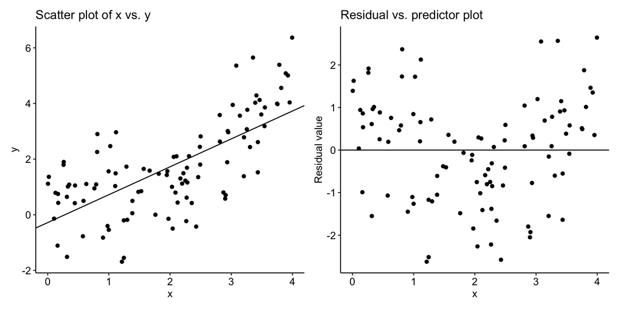

```r
library(patchwork)
n <- 100
x <- runif(n, 0, 4)
e <- rnorm(n)
y <- 1 - x + 2 * (x/2)^2 + e
dat <- data.frame(x, y)
lm_fit <- lm(y ~ x)
dat$resid <- residuals(lm_fit)
p1 <- ggplot(dat, aes(x = x, y = y)) +
  geom_point() +
  geom_abline(slope = lm_fit$coefficients[2],
              intercept = lm_fit$coefficients[1]) +
  ylab("y") +
  ggtitle("Scatter plot of x vs. y") +
  theme_pubr()
p2 <- ggplot(dat, aes(x = x, y = resid)) +
  geom_point() +
  geom_hline(yintercept = 0) +
  ylab("Residual value") +
  ggtitle("Residual vs. predictor plot") +
  theme_pubr()
p1 + p2
```

## The error terms do not have equal variance

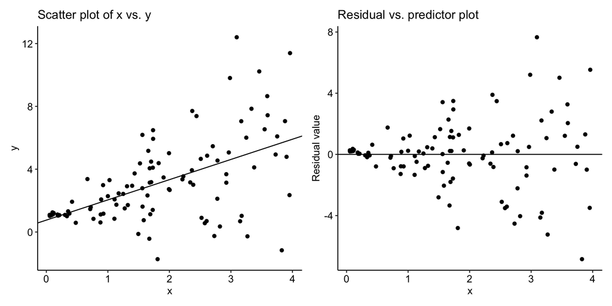

```r
library(patchwork)
n <- 100
x <- runif(n, 0, 4)
e <- rnorm(n, sd = x)
y <- 1 + x + e
dat <- data.frame(x, y)
lm_fit <- lm(y ~ x)
dat$resid <- residuals(lm_fit)
p1 <- ggplot(dat, aes(x = x, y = y)) +
  geom_point() +
  geom_abline(slope = lm_fit$coefficients[2],
              intercept = lm_fit$coefficients[1]) +
  ylab("y") +
  ggtitle("Scatter plot of x vs. y") +
  theme_pubr()
p2 <- ggplot(dat, aes(x = x, y = resid)) +
  geom_point() +
  geom_hline(yintercept = 0) +
  ylab("Residual value") +
  ggtitle("Residual vs. predictor plot") +
  theme_pubr()
p1 + p2
```

## The error terms are not independent

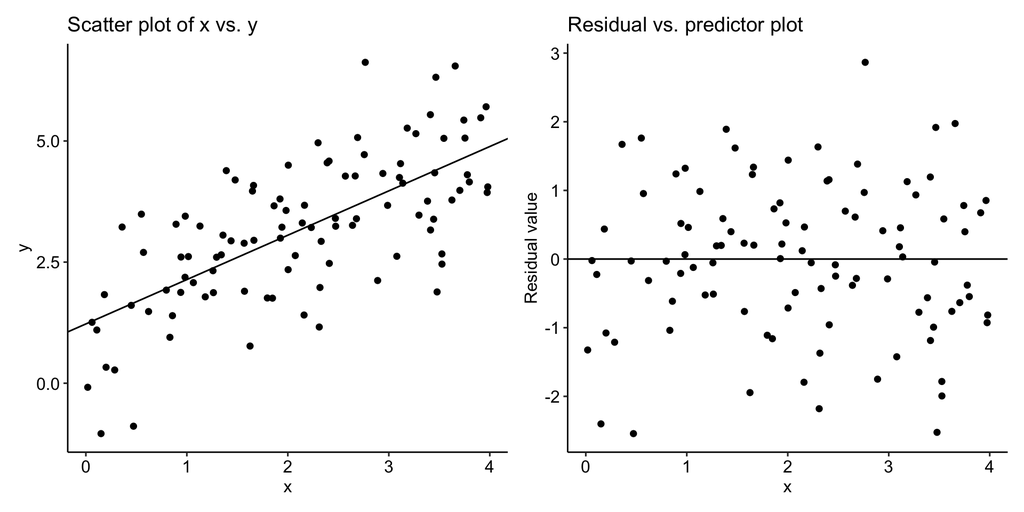

```r
library(patchwork)
n <- 100
x <- runif(n, 0, 4)
e <- numeric(n)
# generating e to be autocorrelated in time
e[1] <- rnorm(1)
for (i in 2:n) {
  e[i] <- sqrt(.75) * e[i-1] + rnorm(1, sd = sqrt(.25))
}
y <- 1 + x + e
dat <- data.frame(x, y)
lm_fit <- lm(y ~ x)
dat$resid <- residuals(lm_fit)
p1 <- ggplot(dat, aes(x = x, y = y)) +
  geom_point() +
  geom_abline(slope = lm_fit$coefficients[2],
              intercept = lm_fit$coefficients[1]) +
  ylab("y") +
  ggtitle("Scatter plot of x vs. y") +
  theme_pubr()
p2 <- ggplot(dat, aes(x = x, y = resid)) +
  geom_point() +
  geom_hline(yintercept = 0) +
  ylab("Residual value") +
  ggtitle("Residual vs. predictor plot") +
  theme_pubr()
p1 + p2
```

## The error terms are not independent

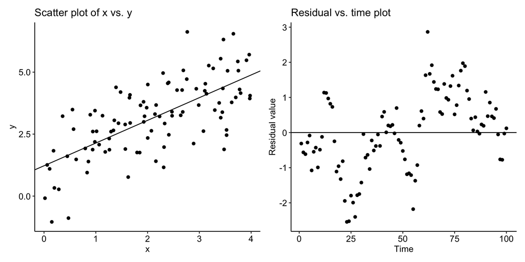

```r
p2 <- ggplot(dat, aes(x = 1:100, y = resid)) +
  geom_point() +
  geom_hline(yintercept = 0) +
  ylab("Residual value") +
  xlab("Time") +
  ggtitle("Residual vs. time plot") +
  theme_pubr()
p1 + p2
```

## The model fits all but one or a few outliers

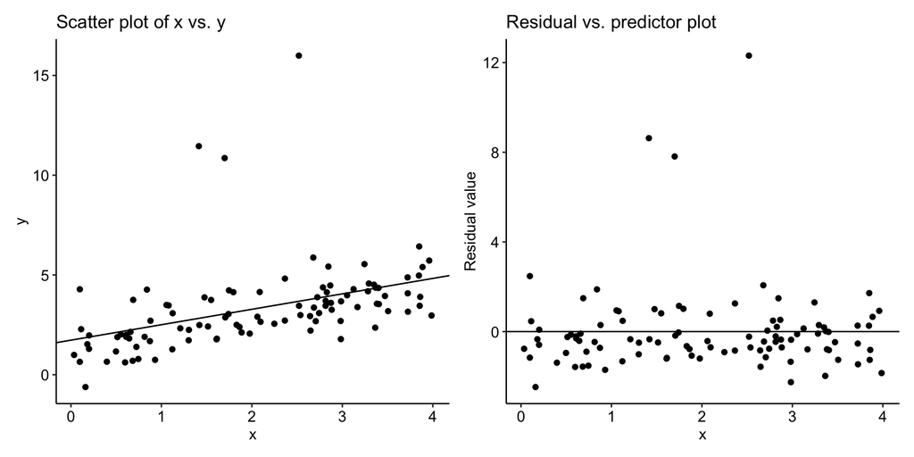

```r
n <- 100
x <- runif(n, 0, 4)
e <- rnorm(n)
y <- 1 + x + e
# force first three observations to be outliers
y[1:3] <- 5 + 4 * x[1:3] + e[1:3]
dat <- data.frame(x, y)
lm_fit <- lm(y ~ x)
dat$resid <- residuals(lm_fit)
p1 <- ggplot(dat, aes(x = x, y = y)) +
  geom_point() +
  geom_abline(slope = lm_fit$coefficients[2],
              intercept = lm_fit$coefficients[1]) +
  ylab("y") +
  ggtitle("Scatter plot of x vs. y") +
  theme_pubr()
p2 <- ggplot(dat, aes(x = x, y = resid)) +
  geom_point() +
  geom_hline(yintercept = 0) +
  ylab("Residual value") +
  ggtitle("Residual vs. predictor plot") +
  theme_pubr()
p1 + p2
```

## The error terms are not normally distributed

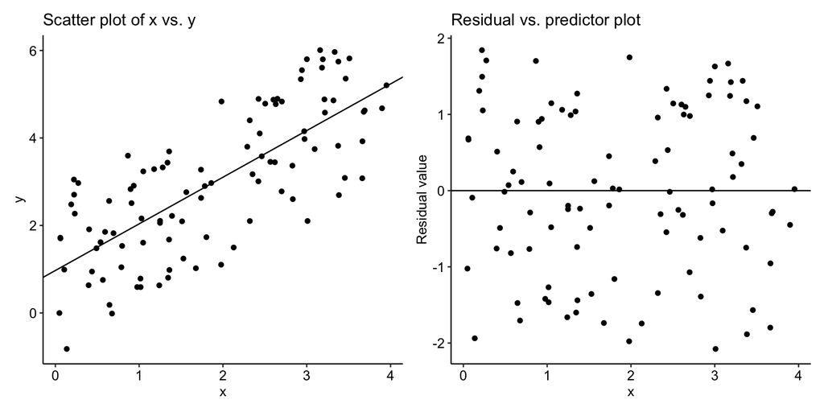

```r
n <- 100
x <- runif(n, 0, 4)
e <- runif(n, -2, 2)
y <- 1 + x + e
dat <- data.frame(x, y)
lm_fit <- lm(y ~ x)
dat$resid <- residuals(lm_fit)
p1 <- ggplot(dat, aes(x = x, y = y)) +
  geom_point() +
  geom_abline(slope = lm_fit$coefficients[2],
              intercept = lm_fit$coefficients[1]) +
  ylab("y") +
  ggtitle("Scatter plot of x vs. y") +
  theme_pubr()
p2 <- ggplot(dat, aes(x = x, y = resid)) +
  geom_point() +
  geom_hline(yintercept = 0) +
  ylab("Residual value") +
  ggtitle("Residual vs. predictor plot") +
  theme_pubr()
p1 + p2
```

## The error terms are not normally distributed

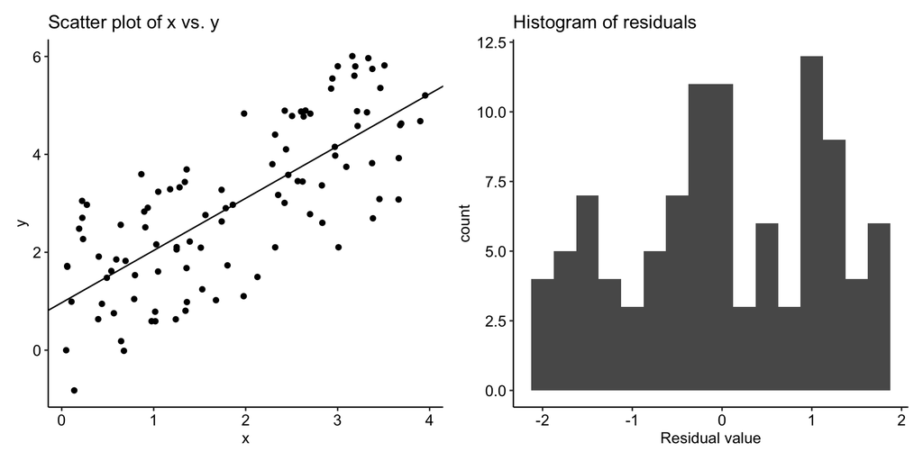

```r
p2 <- ggplot(dat, aes(x = resid)) +
  geom_histogram(binwidth = .25) +
  xlab("Residual value") +
  ggtitle("Histogram of residuals") +
  theme_pubr()
p1 + p2
```

## The error terms are not normally distributed

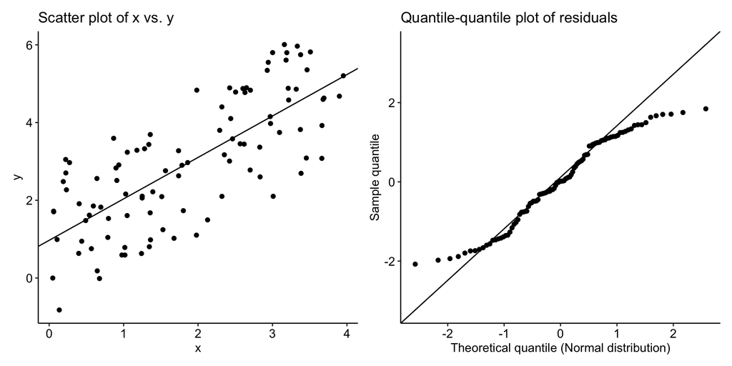

```r
p2 <- ggplot(dat, aes(sample = resid)) +
  geom_qq_line() +
  geom_qq() +
  xlab("Theoretical quantile (Normal distribution)") +
  ylab("Sample quantile") +
  ggtitle("Quantile-quantile plot of residuals") +
  theme_pubr()
p1 + p2
```

## Assessing model fit: example

Do you notice any issues with the following residual vs. predictor plot?

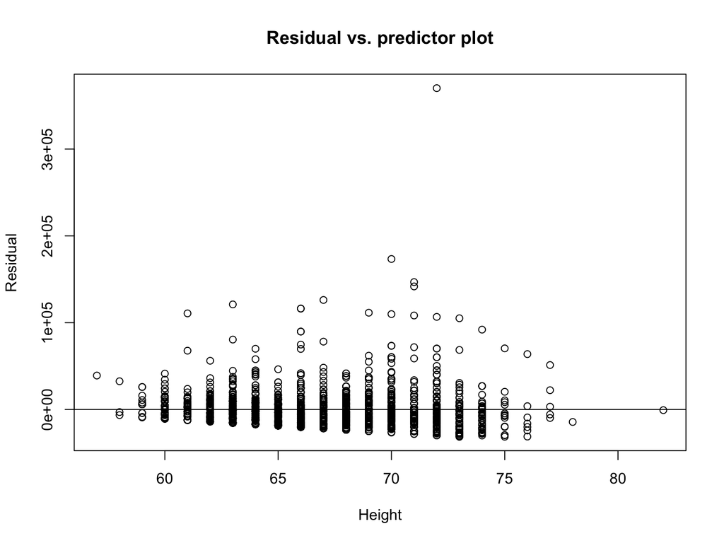

```r
data(earnings)
lm_fit <- lm(earn ~ height, data = earnings)
plot(earnings$height, resid(lm_fit),
     xlab = "Height", ylab = "Residual",
     main = "Residual vs. predictor plot")
abline(0, 0)
```

## Assessing model fit: example

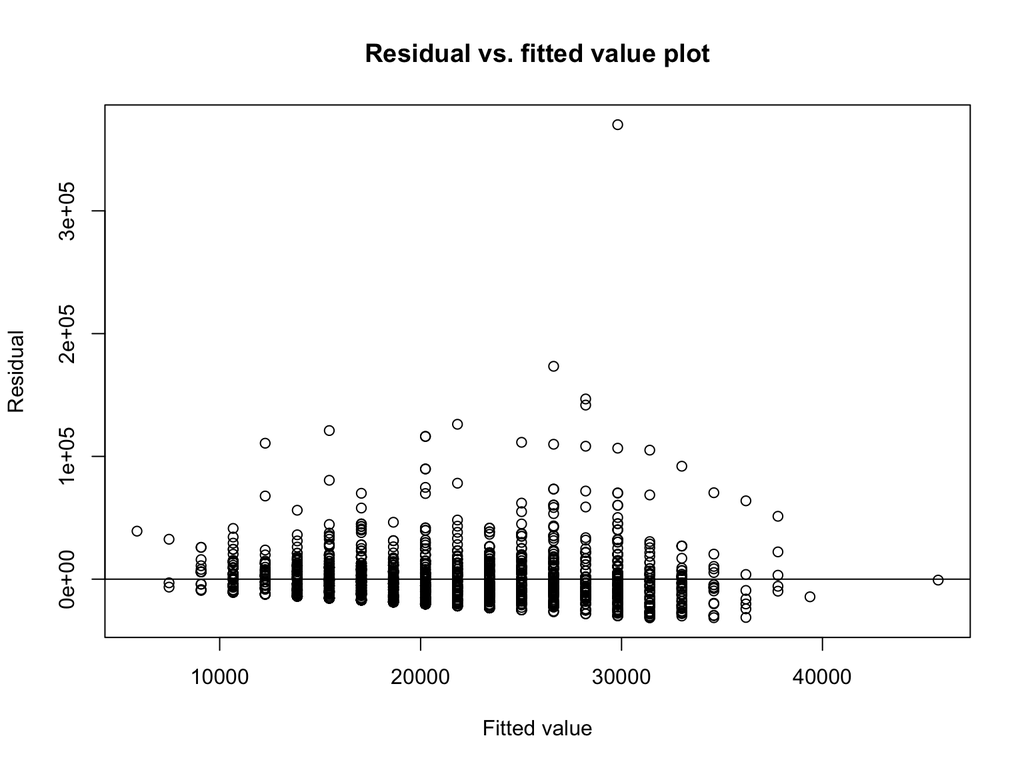

```r
plot(fitted(lm_fit), resid(lm_fit),
     xlab = "Fitted value", ylab = "Residual",
     main = "Residual vs. fitted value plot")
abline(0, 0)
```

## Assessing model fit: example

Do you notice any issues with the following quantile-quantile plot?

```r
qqnorm(y = resid(lm_fit))
qqline(resid(lm_fit))
```

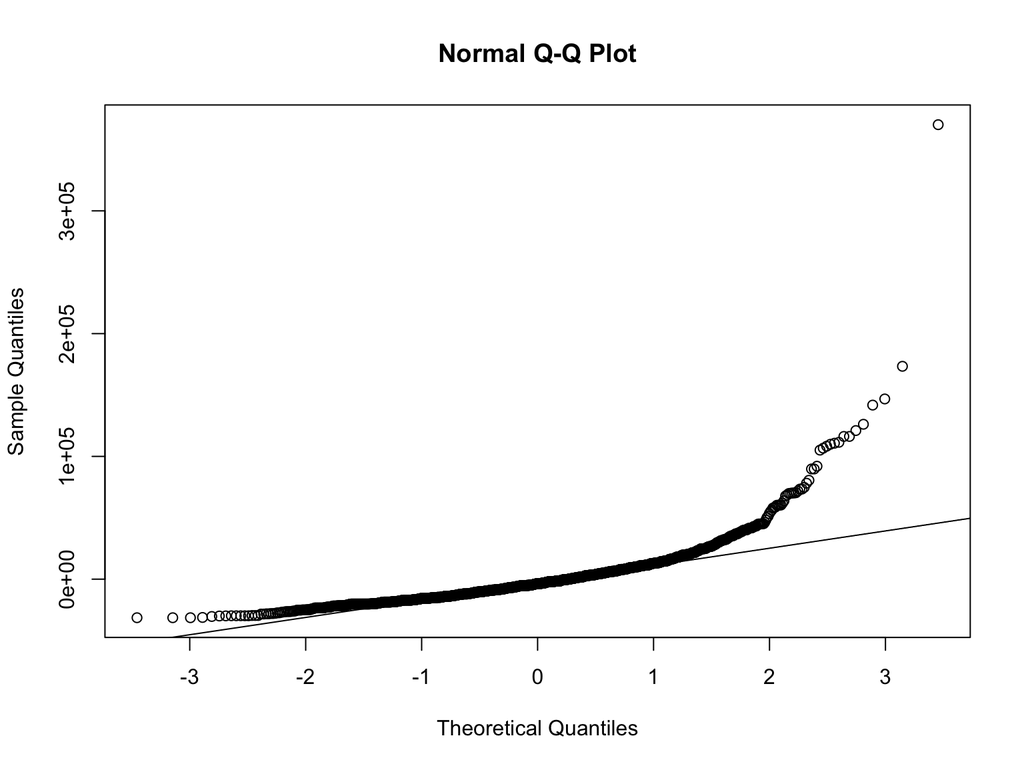

## Assessing model fit: penguins

Do you notice any issues with the following residual plot?

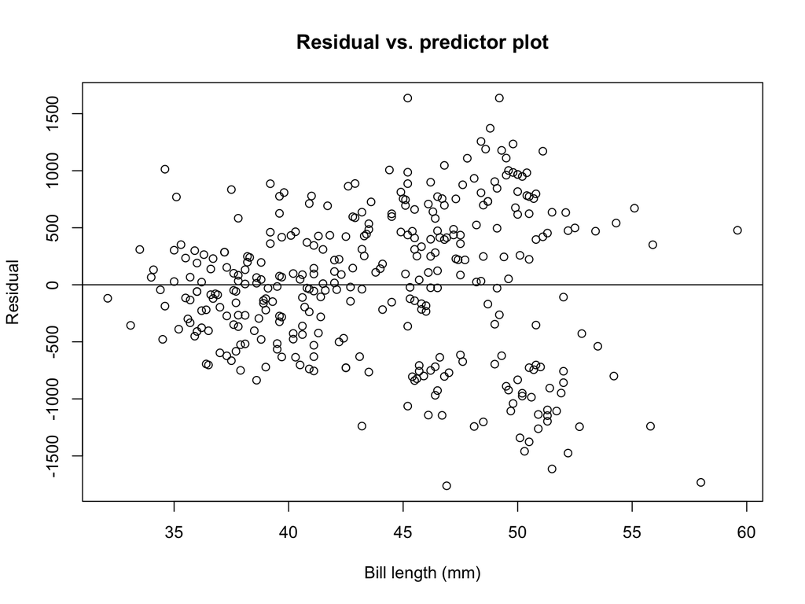

```r
library(palmerpenguins)
data(penguins)
penguins <- penguins |>
  filter(!is.na(body_mass_g) & !is.na(bill_length_mm))
lm_fit <- lm(body_mass_g ~ bill_length_mm, data = penguins)
plot(na.omit(penguins$bill_length_mm), resid(lm_fit),
     xlab = "Bill length (mm)", ylab = "Residual",
     main = "Residual vs. predictor plot")
abline(0, 0)
```

## Assessing model fit: penguins

Sometimes it can help to be creative when assessing model assumptions:

[figure not shown]

```r
plot(penguins$bill_length_mm, resid(lm_fit),
     col = penguins$species,
     xlab = "Bill length (mm)", ylab = "Residual",
     main = "Residual vs. predictor plot")
legend("topright", col = 1:3, legend = unique(penguins$species), pch = 1)
abline(0, 0)
```

## Assessing model fit: penguins

Sometimes it can help to be creative when assessing model assumptions:

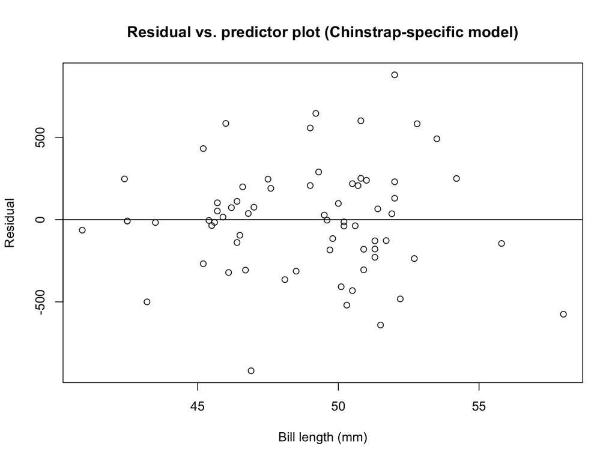

```r
chinstrap <- penguins |>
  filter(species == "Chinstrap")
chinstrap_fit <- lm(body_mass_g ~ bill_length_mm, data = chinstrap)
plot(chinstrap$bill_length_mm, resid(chinstrap_fit),
     xlab = "Bill length (mm)", ylab = "Residual",
     main = "Residual vs. predictor plot (Chinstrap-specific model)")
abline(0, 0)
```

## Assessing model fit using external validation

A direct way to assess model fit is to use it to make predictions and then compare those predictions to actual data. However, to avoid overfitting, we must validate the model using data that are independent and external to the training data set.

If we have no external data, cross validation can also be used to assess the model fit.

## Remedial measures

If the simple linear regression model is not appropriate, the two paths forward are:

1. Develop and use a more appropriate model.
2. Transform the data so that the simple linear regression model is appropriate for the transformed data.

KNNL Chapter 3.8 provides an overview of some strategies for dealing with common issues. For now, it is enough to identify the issues and discuss how they may affect your analysis. In later weeks, we will discuss some of these strategies in detail.

## Coding exercises

Generate a dataset that breaks one of the assumptions (just one!) of the normal error simple linear regression model. Without revealing the code used to generate the data, swap datasets with a classmate and challenge them to figure out which assumption you broke.

## P-Hacking Challenge

Download the data from the pre-course survey on Canvas.

1. Choose a response variable and a predictor for which you believe a linear association exists. Fit a simple linear regression. What are your estimated slope and intercept?
2. Identify the pair of variables which appear to have the strongest linear association. Without terms we haven’t covered yet, like “p-value” or “r-squared,” explain how you determine what counts as a “strong” linear relationship.